# Homework8

Victor Aluko

15 April 2017

## Exercise 1

Below is the solution for the exercise.

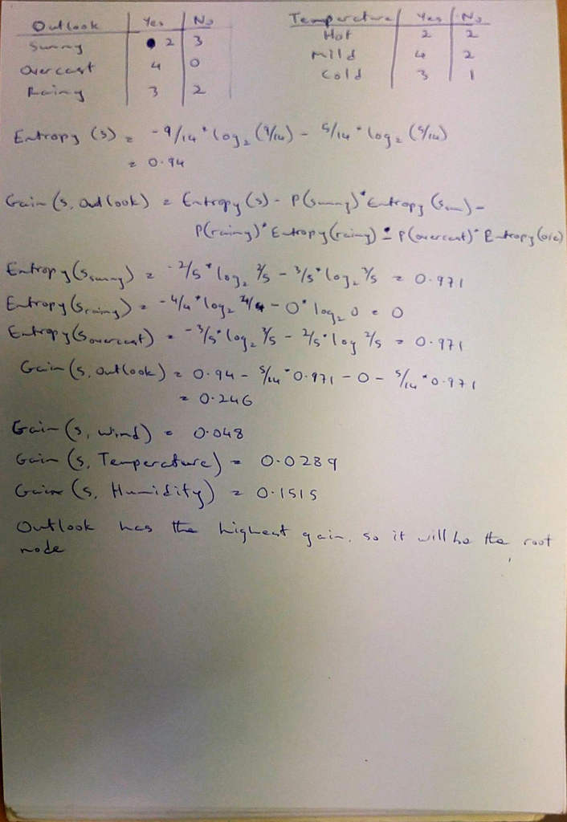

Page 1

And page 2

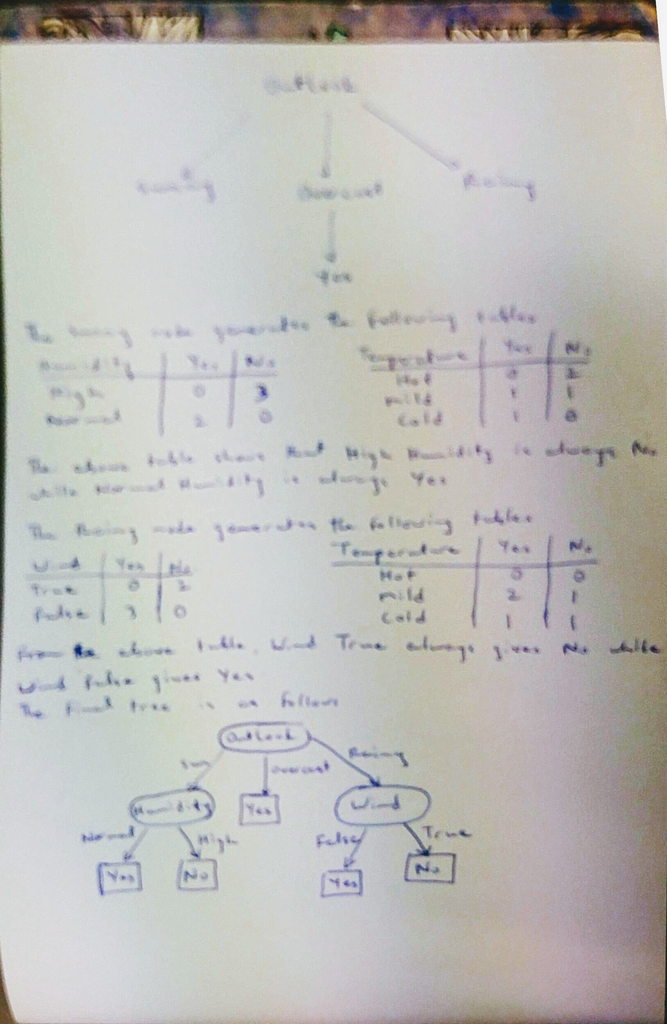

Page 2

Based on the tree above,

| Outlook | Temp | Humidity | Windy | Play |
| --- | --- | --- | --- | --- |
| SUnny | Cool | High | TRUE | No |

## Exercise 2

The calculation for the Naive Bayelsian is given below:

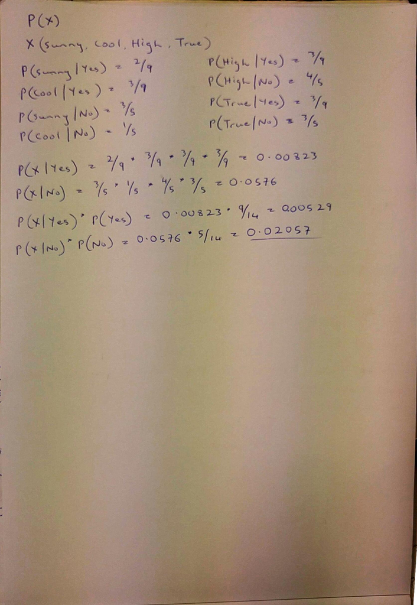

Page 2

The naive Bayesian predicts that “Sunny Cool High TRUE” is NO.

## Exercise 3

The calculation for the KNN using Manhattan distance is given below:

[figure not shown]

KNN Calculation

## Exercise 4

For this exercise, I generated the classifier for naive Bayesian and J48 using the code attached with this report. I used 80% of the data to train the classifier and 20% to test the trained classifier.

The table below shows the predicted value from the naive Bayesian classier

```r
NB <- make_Weka_classifier("weka/classifiers/bayes/NaiveBayes")

nb_weka_model <- NB(loan ~ ., data=trainBankData, na.action = NULL)
nb_classifier <- evaluate_Weka_classifier(nb_weka_model, numFolds = 5, class = TRUE)

nb_test_predict <- predict(nb_weka_model, testBankData[,-loan_col_num])

table(pred=nb_test_predict,true=testBankData$loan)
```

```
##      true
## pred    no  yes
##   no  7098 1230
##   yes  384  175
```

The Mean of the naive Bayesian classifier is given below:

```r
mean(nb_test_predict==testBankData$loan)
```

```
## [1] 0.8183864
```

We a classifier mean of over 0.8 is very good. Also, the classifier had a very godd accuracy for the No values of the loan.

Using the J48 classifier, the predicted table values are:

```r
j48_weka_model <- J48(loan~., data=trainBankData)
j48_classifier <- evaluate_Weka_classifier(j48_weka_model, numFolds = 5, class = TRUE)

j48_test_predict <- predict(j48_weka_model,testBankData[,-loan_col_num])

table(pred=j48_test_predict,true=testBankData$loan)
```

```
##      true
## pred    no  yes
##   no  7321 1271
##   yes  161  134
```

```r
mean(j48_test_predict==testBankData$loan)
```

```
## [1] 0.8388658
```

The value from the mean also gives a very good goodness which is sufficient

## Exercise 5

```r
rf_classifier <- randomForest(loan ~ ., data=trainBankData)

rf_test_predict <- predict(rf_classifier, testBankData[,-loan_col_num])

table(pred=rf_test_predict,true=testBankData$loan)
```

```
##      true
## pred    no  yes
##   no  7389 1284
##   yes   93  121
```

and the mean is given below

```r
mean(rf_test_predict==testBankData$loan)
```

```
## [1] 0.8450546
```

The importance analysis from the classifier is also given below:

```r
importance(rf_classifier,type = 2)
```

```
##           MeanDecreaseGini
## age             1195.22782
## job              684.39351
## marital          232.04706
## education        226.43255
## default           58.30971
## balance         1764.45335
## housing          171.61597
## contact          172.80978
## day             1015.98475
## month            622.73154
## duration        1541.51288
## campaign         636.80681
## pdays            275.65421
## previous         183.94952
## poutcome          95.75969
## y                 63.65131
```